# Stats 506, F20, Final Project

Jialun Li, ljlstudy@umich.edu

December 06, 2020

# Introduction

Different commercial buildings have different operation times. Moreover, their operation times may vary from buildings to buildings due to different regulations of companies. However, There may exists some common patterns for the operating time in one specific division, or in one specific building types (Office, shopping mall, lodging houses, etc.).

Hence, in my final project, I decided to carry out analysis to answer this question: **For what portion of the day are different types of commercial** **buildings typically in use?**

This analysis may be helpful for further energy consumption analysis. For example, buildings in longer operating time may have more energy consumed and this analysis will point out which type of commercial buildings or commercial buildings in which division are in heavily operation each day.

I will analyze *the mean working hours* and *proportion of working hour* *categories* for buildings in each division and principal building activities. Moreover, considering that the square footage of buildings (`SQFT`) may affect the final result, besides the per-building analysis, I will also do per-square-footage analysis.

# Data & Methods

The data set I planned to use is the 2012 US Commercial Building Energy Consumption Survey (CBECS) data.

My data analysis steps include:

1. Read in the data set (including replicate weights and the code book).
2. Clean the data, select variables in interest and assign labels to the levels of the categorical variables. The main variables I will use is: `PUBID`, `CENDIV`, `PBA`, `SQFT`, `WKHRS`, `WKHRSC`, `FINALWT`, `FINALWT1-197` and *imputed* variables. For imputed data, I will only use the reported rows.
3. Compute the mean and proportions for the working hours grouped by division and principal building activities.
4. Compute the variance using replicate weights and get the corresponding confidence intervals.
5. Summarize the data into graphs and tables for presentation and get conclusions.

The source code can be found at: https://github.com/CataphractLi/Stats506_public/tree/master/Final%20Project

# Results

Note: There are some problems in the confidence intervals for the proportions hence I do not plot them.

## Per Building Analysis

The mean working hours for different divisions and different principal building activities are:

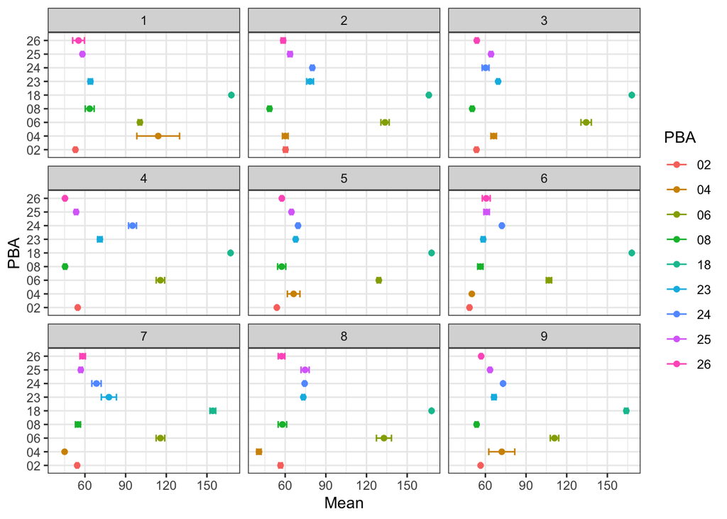

| PBA | 1 | 2 | 3 | 4 | 5 | 6 | 7 | 8 | 9 |
| --- | --- | --- | --- | --- | --- | --- | --- | --- | --- |
| 02 | 53.0 (52.0, 53.9) | 60.3 (58.9, 61.7) | 53.4 (52.4, 54.4) | 54.7 (54.0, 55.3) | 53.8 (53.4, 54.3) | 48.3 (47.5, 49.0) | 54.3 (53.4, 55.1) | 56.6 (55.3, 57.9) | 56.5 (56.0, 56.9) |
| 04 | 114.0 (98.3, 129.8) | 60.1 (58.0, 62.2) | 66.1 (64.1, 68.2) | NA | 66.3 (61.6, 70.9) | 50.0 ( NaN, NaN) | 45.0 ( NaN, NaN) | 40.7 (39.0, 42.3) | 72.1 (62.5, 81.7) |
| 06 | 100.6 (99.2, 101.9) | 133.7 (130.6, 136.7) | 134.3 (130.5, 138.2) | 115.7 (112.6, 118.8) | 129.1 (127.8, 130.4) | 106.9 (104.9, 108.9) | 115.7 (112.5, 118.8) | 132.9 (127.3, 138.4) | 111.0 (107.9, 114.1) |
| 08 | 63.5 (60.2, 66.8) | 48.5 (47.3, 49.7) | 50.3 (49.2, 51.3) | 45.3 (44.3, 46.4) | 57.4 (54.4, 60.5) | 56.3 (54.3, 58.3) | 54.9 (53.0, 56.7) | 58.0 (54.8, 61.1) | 53.5 (52.4, 54.6) |
| 18 | 168.0 (168.0, 168.0) | 166.0 (165.4, 166.6) | 168.0 (168.0, 168.0) | 167.4 (167.2, 167.6) | 168.0 (168.0, 168.0) | 168.0 (168.0, 168.0) | 154.3 (152.2, 156.5) | 168.0 (168.0, 168.0) | 164.0 (162.7, 165.2) |
| 23 | 64.0 (62.5, 65.5) | 78.4 (75.9, 80.9) | 69.4 (68.5, 70.3) | 71.0 (69.4, 72.7) | 67.7 (66.7, 68.8) | 58.4 (57.0, 59.7) | 77.6 (72.1, 83.2) | 73.4 (72.3, 74.4) | 66.4 (64.8, 67.9) |
| 25 | 58.1 (57.3, 59.0) | 63.6 (62.1, 65.1) | 64.2 (63.1, 65.3) | 53.5 (52.3, 54.6) | 64.6 (63.7, 65.6) | 60.9 (58.9, 62.9) | 56.9 (55.7, 58.2) | 74.7 (71.7, 77.7) | 63.4 (62.6, 64.3) |
| 26 | 55.3 (50.9, 59.6) | 58.5 (57.0, 60.0) | 53.7 (52.7, 54.7) | 45.3 (44.6, 46.0) | 57.5 (56.8, 58.3) | 60.6 (57.7, 63.5) | 58.3 (56.3, 60.3) | 57.3 (54.9, 59.8) | 56.9 (56.1, 57.6) |
| 24 | NA | 80.0 (79.0, 81.1) | 60.1 (57.6, 62.7) | 95.1 (92.2, 98.0) | 69.5 (68.6, 70.4) | 72.2 (71.5, 72.8) | 68.5 (65.1, 71.9) | 74.4 (73.7, 75.0) | 73.0 (72.9, 73.2) |

The proportions for working hour categories for different divisions and different principal building activities are:

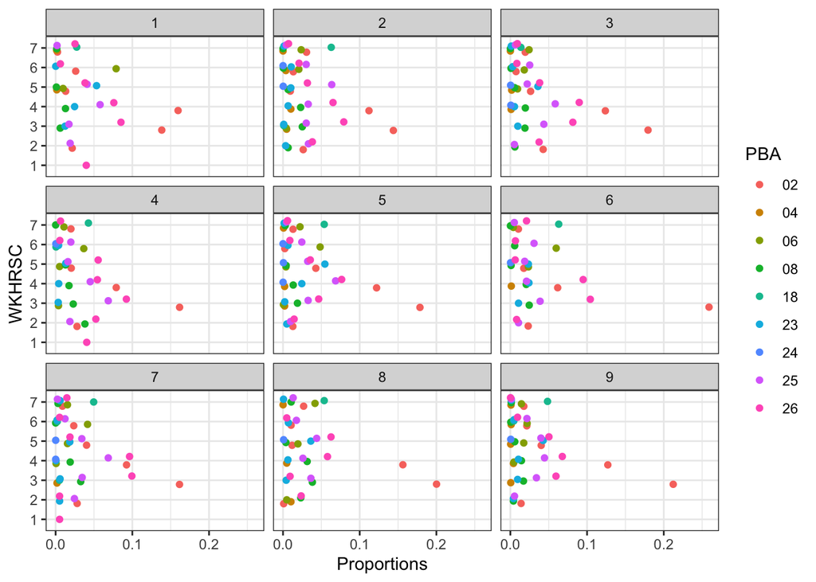

## Per Square Footage Analysis

The mean working hours for different divisions and different principal building activities are:

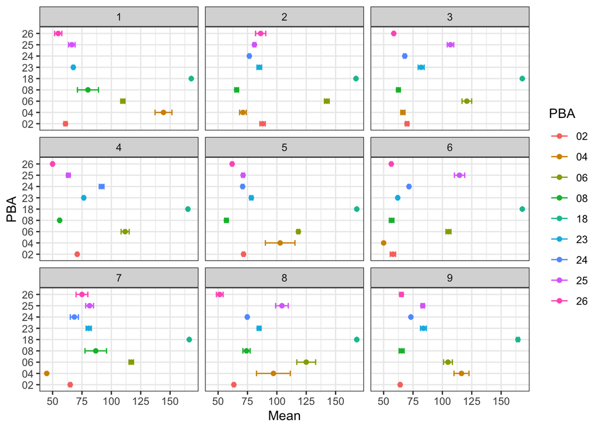

| PBA | 1 | 2 | 3 | 4 | 5 | 6 | 7 | 8 | 9 |
| --- | --- | --- | --- | --- | --- | --- | --- | --- | --- |
| 02 | 61.0 (59.6, 62.3) | 87.8 (85.5, 90.1) | 69.9 (68.4, 71.4) | 70.9 (70.3, 71.6) | 71.6 (70.6, 72.6) | 57.9 (55.6, 60.2) | 65.0 (64.1, 65.9) | 63.4 (62.6, 64.2) | 64.1 (63.3, 64.8) |
| 04 | 144.4 (137.2, 151.6) | 71.1 (68.3, 74.0) | 66.4 (64.6, 68.2) | NA | 102.8 (90.2, 115.4) | 50.0 ( NaN, NaN) | 45.0 ( NaN, NaN) | 97.1 (82.7, 111.4) | 116.3 (109.9, 122.6) |
| 06 | 109.8 (108.0, 111.6) | 142.5 (140.5, 144.5) | 120.8 (116.7, 124.9) | 111.7 (108.3, 115.2) | 118.3 (117.1, 119.5) | 105.2 (103.0, 107.3) | 116.9 (115.0, 118.8) | 125.0 (117.0, 133.0) | 104.7 (101.0, 108.5) |
| 08 | 80.1 (71.1, 89.0) | 65.8 (64.2, 67.4) | 62.6 (61.0, 64.2) | 56.0 (55.4, 56.5) | 57.1 (55.5, 58.6) | 56.8 (54.9, 58.7) | 86.7 (77.6, 95.9) | 74.1 (71.1, 77.2) | 65.3 (63.2, 67.5) |
| 18 | 168.0 (168.0, 168.0) | 167.3 (167.1, 167.5) | 168.0 (168.0, 168.0) | 165.2 (164.7, 165.7) | 168.0 (168.0, 168.0) | 168.0 (168.0, 168.0) | 166.3 (166.0, 166.6) | 168.0 (168.0, 168.0) | 164.3 (163.2, 165.4) |
| 23 | 67.6 (66.8, 68.4) | 85.1 (83.1, 87.0) | 81.9 (79.4, 84.5) | 76.5 (75.8, 77.1) | 78.2 (76.9, 79.6) | 62.0 (61.4, 62.6) | 80.8 (78.5, 83.0) | 84.9 (83.3, 86.5) | 83.9 (81.4, 86.4) |
| 25 | 66.4 (63.5, 69.2) | 80.9 (79.7, 82.1) | 106.9 (104.1, 109.7) | 63.4 (61.9, 65.0) | 71.3 (70.0, 72.5) | 114.6 (110.2, 119.0) | 81.5 (78.2, 84.8) | 104.3 (98.9, 109.7) | 83.3 (81.8, 84.7) |
| 26 | 54.8 (51.7, 57.8) | 86.2 (81.9, 90.5) | 58.6 (58.1, 59.2) | 50.0 (49.2, 50.8) | 61.9 (61.1, 62.7) | 56.5 (55.8, 57.2) | 75.0 (70.0, 80.0) | 51.4 (48.6, 54.3) | 65.1 (63.7, 66.6) |
| 24 | NA | 76.5 (75.7, 77.4) | 68.0 (67.0, 69.0) | 91.7 (89.7, 93.7) | 70.8 (69.9, 71.8) | 71.6 (70.9, 72.3) | 68.5 (65.1, 71.9) | 74.8 (74.1, 75.5) | 73.2 (73.0, 73.3) |

The proportions for working hour categories for different divisions and different principal building activities are:

[figure not shown]

# Conclusion

We can see that buildings with PBA label 18 has the longest operation hours among all census divisions. It operates almost throughout the week. The buildings with PBA label 06 also have relatively long operating hours. For other buildings, the operating time vary from division to division. Buildings with PBA label 04 have significantly longer operating hours in some divisions.

# TODO list

1. Determine why the confidence intervals are extremely wide for proportions.
2. Take the imputed variables like `ZSQFT` into consideration.
3. Think about a more clear way to plot the proportions. (Tables are ready but with many NAs.)
4. Transform the levels into labels and modify the conclusion parts.
5. Add more comments in the Results and Conclusion parts.